# AMMS IBS & IBD Practical

Nick Brazeau, Sophie Berube, Izzy Routledge, Abebe Fola

July 25, 2022

# Dependencies for Practical

Please copy and paste the below code chunk in it’s entirety to your console to download R package libraries needed for this practical. If you are having trouble installing any of the R packages, please ask an instructor for a pre-loaded flash drive.

```r
deps <- c("tidyverse", "vcfR", "MIPanalyzer", "hmmibdr", "sf", "tidygraph", "ggraph")
deps <- !sapply(deps, function(x){x %in% installed.packages()[,1]} )
if(any(deps)) {
  if(deps["hmmibdr"]) {
    if (!"remotes" %in% installed.packages()[,1]){
      install.packages("remotes")
    }
    remotes::install_github("OJWatson/hmmibdr")
    deps <- deps[names(deps) != "hmmibdr"]
  } else if(deps["MIPanalyzer"]) {
    if (!"remotes" %in% installed.packages()[,1]){
      install.packages("remotes")
    }
    remotes::install_github("mrc-ide/MIPanalyzer")
    deps <- deps[names(deps) != "MIPanalyzer"]
  } else {
    install.packages(names(deps)[deps])
  }
}
```

Please now load all of those libraries into this session using the code chunk below. Please copy and paste it in its entirety.

```r
library(tidyverse)
library(vcfR)
library(hmmibdr)
library(sf)
library(tidygraph)
library(ggraph)
library(cowplot)
```

Finally, please source (*i.e.* load) the file called `utils.r` that is stored under the `IBD/R` directory. If you are using the `IBD.Rproj` environment, you can just run `source("R/utils.R")` as below. Or if you are running from a different environment or working directory (`getwd()`), use the `file.choose` function to help locate the file.

```r
source("R/utils.R")
```

# 1 Introduction

## Useful Definitions

During prior sessions, you have explored how to estimate genetic relatedness based on levels of population diversity, structure, and connectivity. In this practical, we will focus on between-parasite, or pairwise, measures of genetic relatedness. These are more “individual” focused measures of relatedness versus population, or deme, focused measures of relatedness.  
There are many ways to estimate relatedness among individuals. One method you may have encountered in the past is [phylogenetic trees](https://en.wikipedia.org/wiki/Phylogenetic_tree), which is a common approach for modeling relationships between bacterial and viral pathogens. However, in recombining pathogens, like malaria, phylogenetic approaches are complicated (due to underlying assumptions of nonrecombining regions). Instead, we can leverage our knowledge about recombination and use it to estimate relatedness through identity.

In the schematic below, a single mosquito has bitten two different individuals infected with a single strain of the malaria parasite, resulting in a superinfection. The two strains (red vs purple) then undergo recombination in the mosquito midgut and produce progeny that are siblings and expected to share half of their genomes on average.

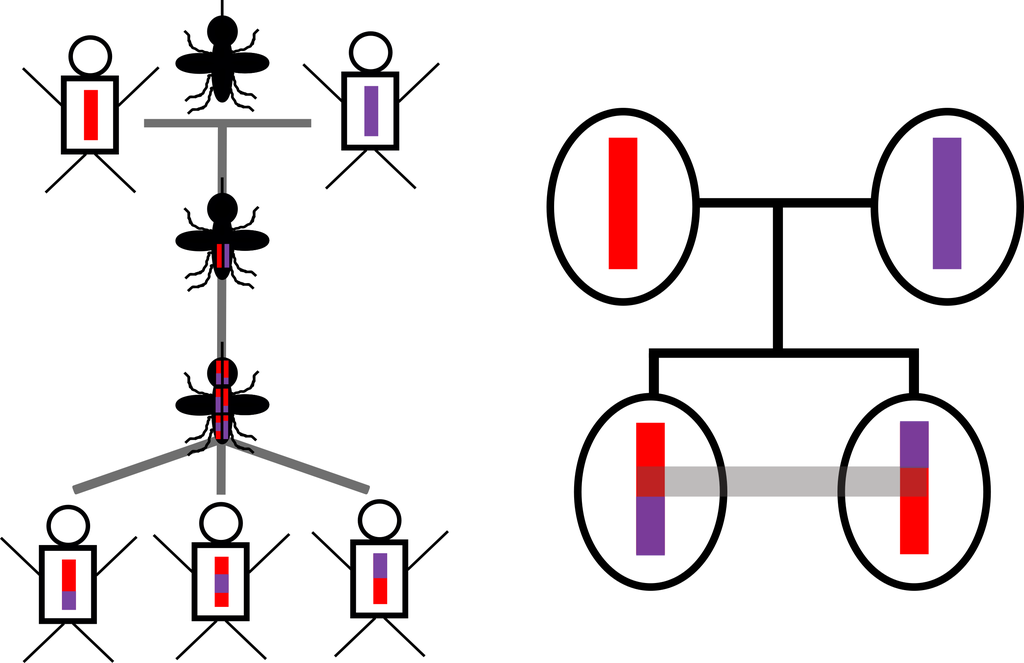

Remember, that recombination and random segregation occurs with homologous chromosome pairing during the process of meiosis. This means that “maternal” and “paternal” genetic material is exchanged to create new “daughter” cells with unique genetic material (e.g. a new, unique haplotype).

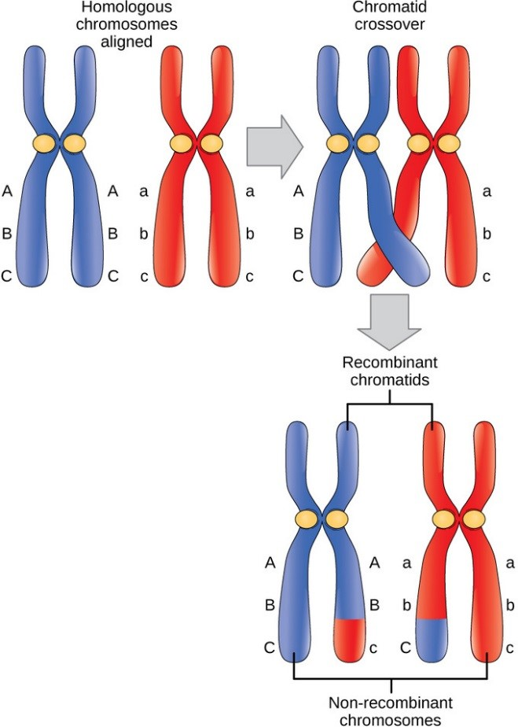

From a population genetics perspective, this exchange of genetic material via recombination can be leveraged to detect strong signals of genetic relatedness between individuals. For example, moving further along in the schematic, the mosquito bites three new hosts and transfers a single strain of “daughter” genetic material (*N.B.*, since only a single strain was transmitted, no cotransmission infections resulted despite the potential). The pedigree on the right shows two of the parasite siblings and highlights how much of their genome is “identical” or, was inherited from the same parent in the same genomic location (identity by descent).  
As a result, one way to conceptualize the genome is as blocks, or segments, that are joined together. Each block has its own unique ancestral history, with a different “tree” of relatedness as depicted in the schematic below. Additionally, as we look further and further back in time, these blocks become smaller and our trees become “deeper”. We will explore this concept that increasing time, or increasing generations, results in smaller blocks (*i.e.* as the number of recombination events increases, blocks are broken into smaller and smaller bits).

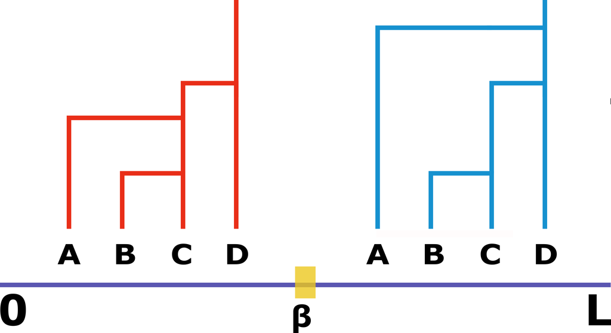

## IBS/IBD Overview {.unnumbered}

As described above, we can consider pairwise relatedness by determining if the genetic sequence at a give position in the genome, a loci, between two parasites is identical (e.g. the same allele). We can either simply measure the number of sites with identical alleles between two individuals, termed identity by state (IBS), or, we can use statistical models to determine if identical alleles and “blocks” of the genome were likely to be inherited from a common ancestor, termed identity by descent (IBD). It is important to note the differences between IBS and IBD: IBS refers to the “state” or realization of the allele at a loci and can be the result of numerous factors other than ancestry (e.g. selection, drift, structure, chance). In contrast, IBD solely refers to inherited genetic material, which follow specific patterns relevant to public health that we will explore below. The differences between IBS and IBD are visualized in the schematic below, where sites may be IBS but not IBD whilst all sites that are IBD are IBS (*N.B.* only true under the classic definition of IBD).

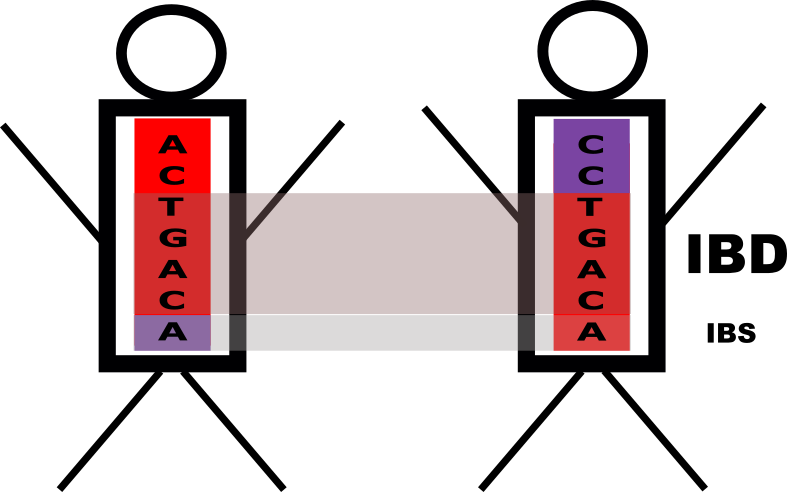